# Testing Clustering methods.

### Test 19

Now let’s combine test 17 and test 18 and calculate the principal components and the angles before clustering.

Run the tests with:

- **PCA calculated using prcomp**
- dbscan clustering.
- **Angles calculated before clustering.**
- number of pathways 4.
- Centroids not assigned in density based methods.

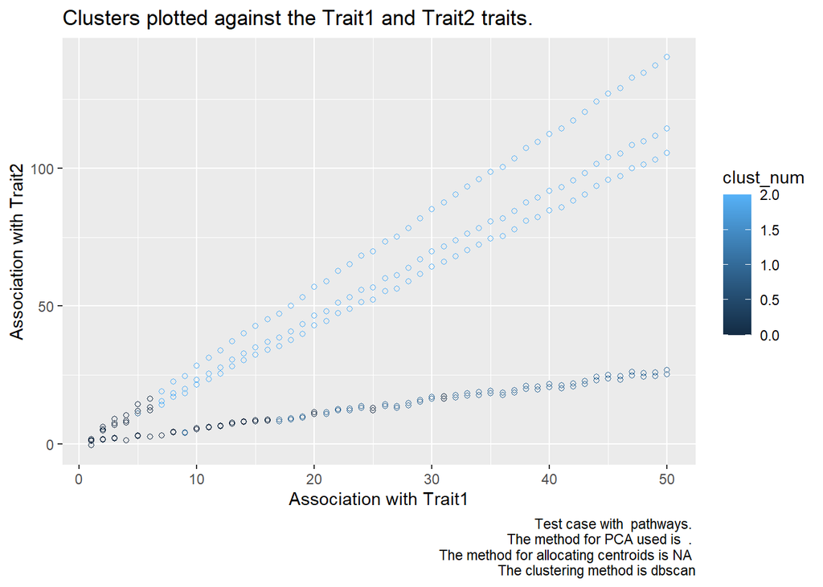

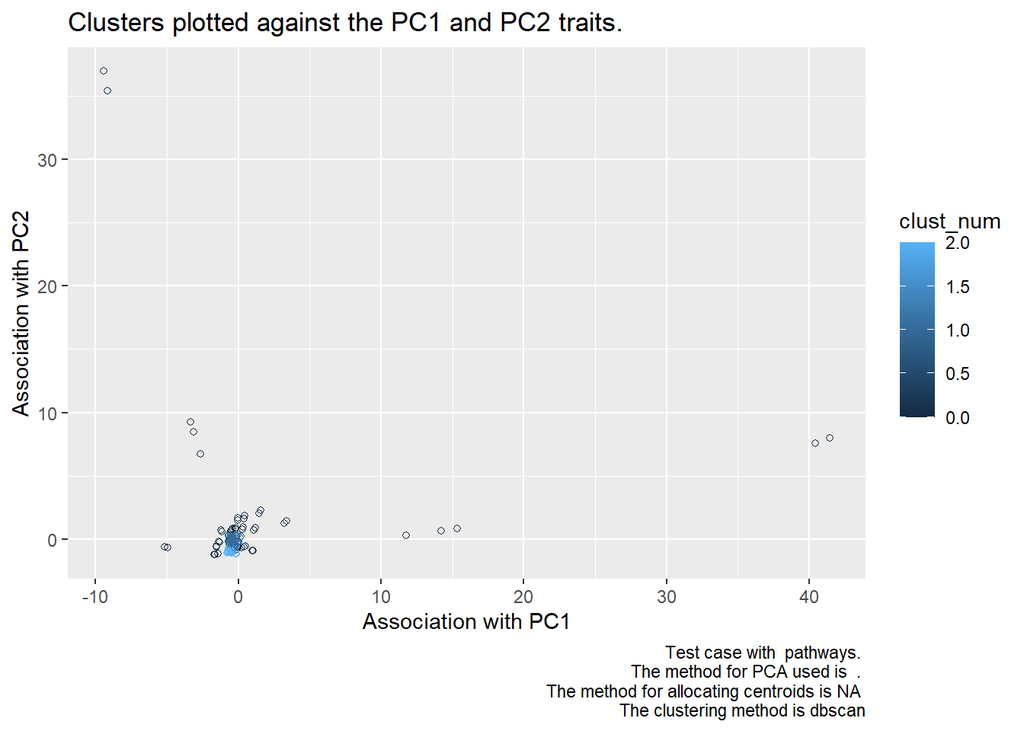

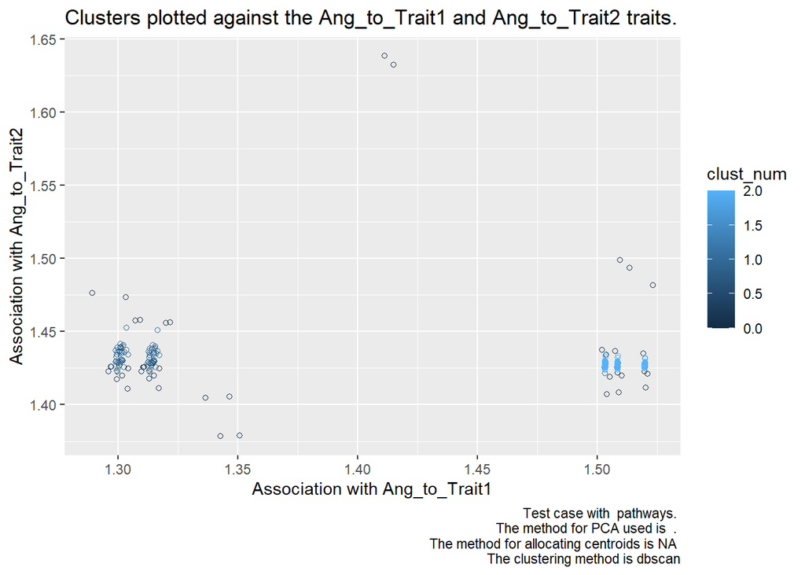

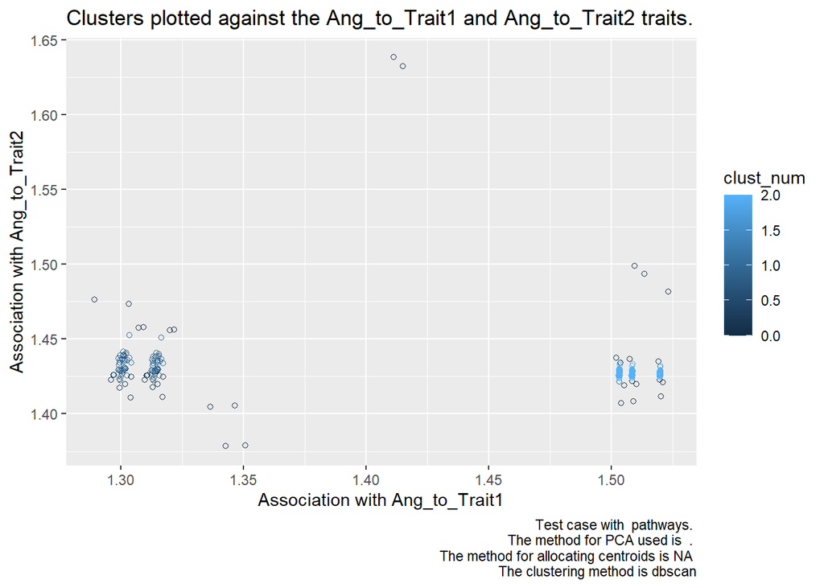

## Vary the density

### Test 20

Now let’s investigate the density parameter to **dbscan**. Let’s make it smaller and try `point_eps = 0.2`.

Run the tests with:

- No PCA
- dbscan clustering.
- **Angles calculated before clustering.**
- number of pathways 4.
- Centroids not assigned in density based methods.

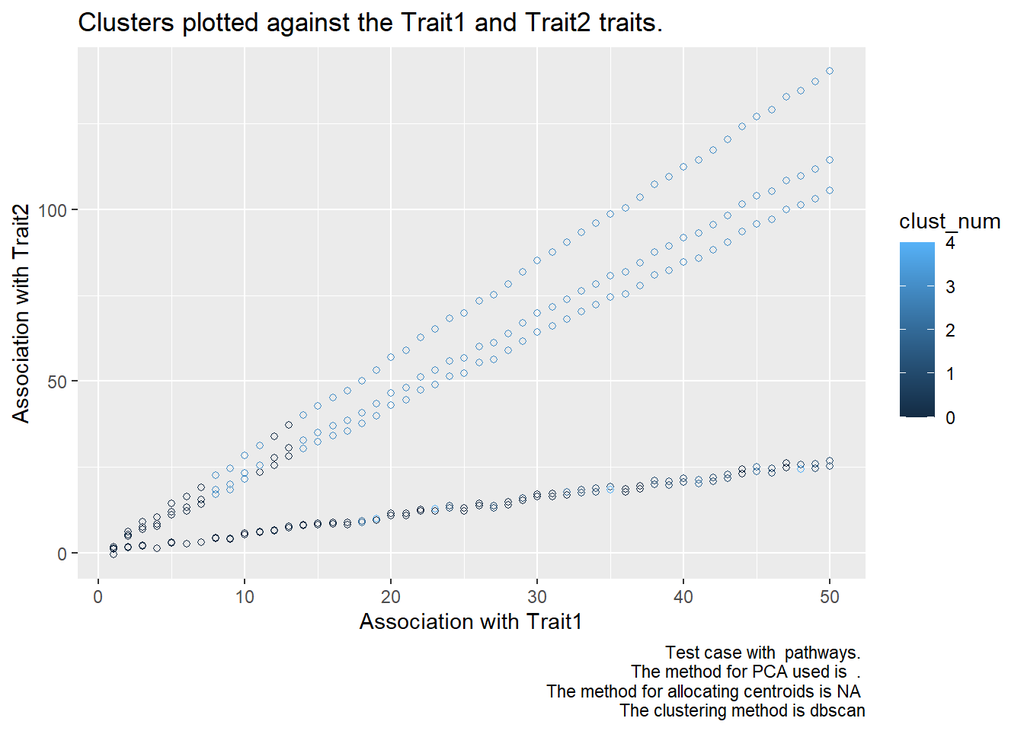

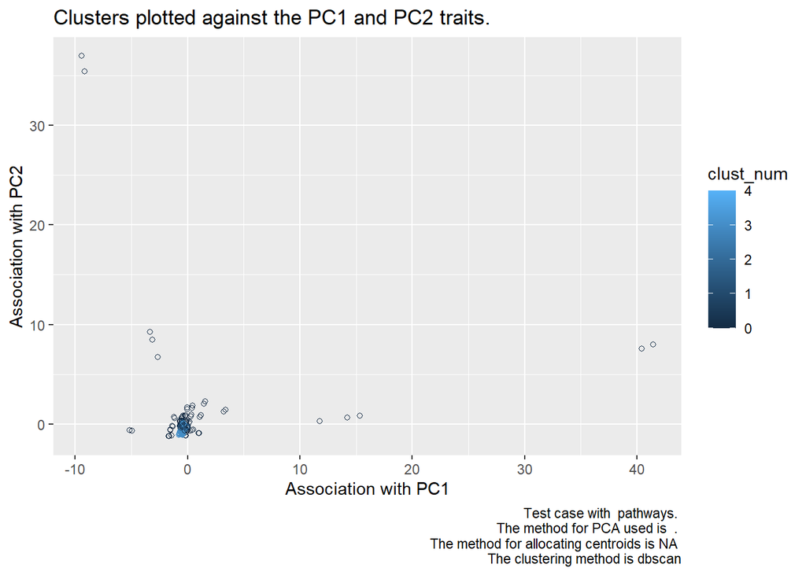

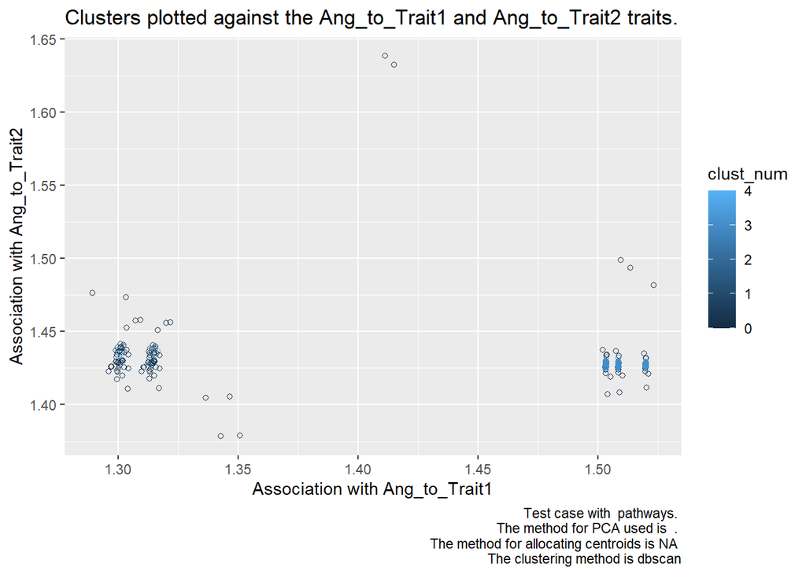

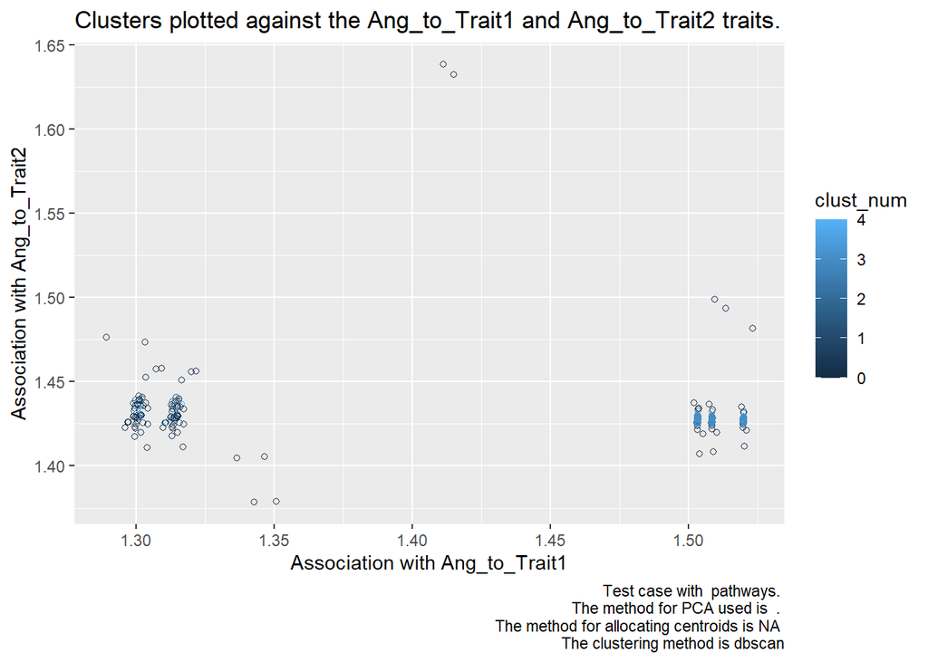

### Test 21

Let’s test the density parameter again but this time increase to `point_eps = 0.8`

Run the tests with:

- No PCA
- dbscan clustering.
- **Angles calculated before clustering.**
- number of pathways 4.
- Centroids not assigned in density based methods.

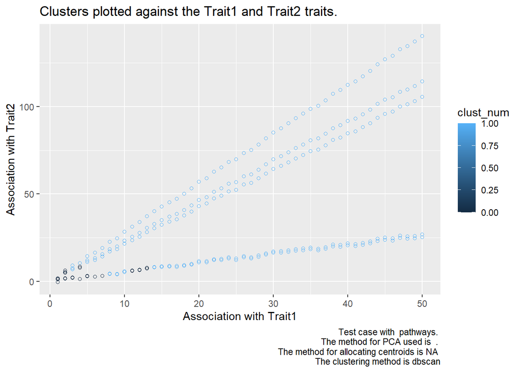

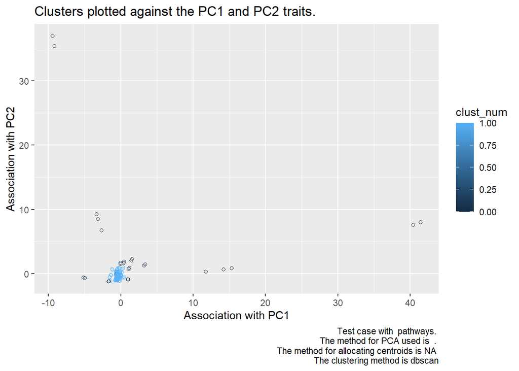

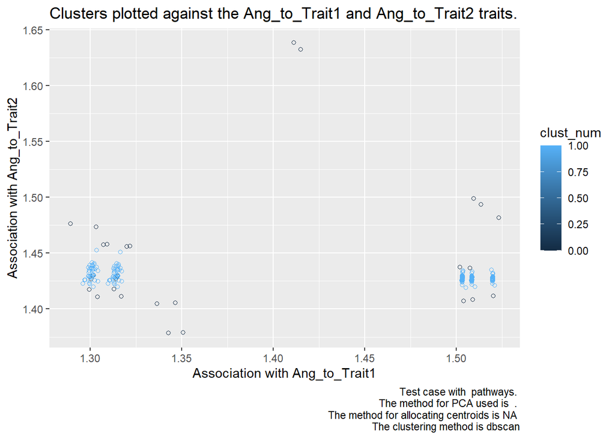

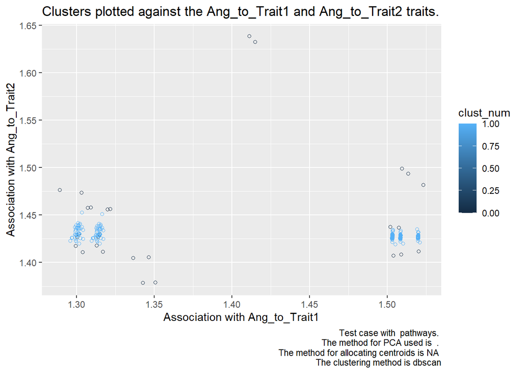